# Homework 2 Key

# Background

You will once again be working with the results of an experiment testing whether ambient lighting levels (measured in lux; see below for more info) affect reading time when college students read the same text on an ereader, but you will now be using data from the full experiment, which compared three different ereaders. The data now includes the full sample of 60 students, who were randomly assigned to one of four lighting levels: 200 lx, 500 lx, 1000 lx, or 1500 lx. Using a factorial design, they were also each assigned to one of three ereaders: a Kindle, a Sony PRS-700, or an i-Rex 1000S (see below for more info). Reading time was used as an indicator of reading ease, where longer times indicate more fatiguing conditions, and was measured in seconds.

The researchers hypothesized that reading time would be shorter under brighter reading conditions but that the effect of lighting would depend on e-reader device. They specifically hypothesized that reading time would be longer on average in the lowest lighting condition(200 lx), which is darker than the average office or classroom, than in the brightest condition (1500lx), which is equivalent to reading outdoors, but that the effect would be stronger (i.e., bigger difference between the lighting levels) for the device with the smaller display (the Sony) than for the two larger displays combined (Kindle and iRex).

# Question 1.

#### What is the DV? What is the IV? Describe each in terms of scale (including what the levels are where applicable) and manipulation (vs. observation). – 8 points

The dependent variable is college students reading time on an e-reader, measured in seconds. Reading time indicates reading ease, with longer times indicating greater fatigue. This is an observed continuous variable. The independent variable is lighting level (manipulated to the four ordinal levels or groups with 200 lx, 500 lx, 1000 lx, or 1500 lx) and type of e-reader (three categorical levels of Kindle, Sony PRS-700, or i_Rex 1000S).

# Question 2.

#### What is the design of this study (i.e., experiment, quasi-experiment, observational)? How do you know? – 6 points

This study is an experiment, since students were randomly assigned to different lighting conditions. The study uses a two-way ANOVA.

# Question 3.

#### Examine side-by-side boxplots for the study and predict whether the researchers’ overall and specific hypotheses are likely to be upheld by statistically significant results. – 16 points

```r
str(hw2_data)
```

```
## 'data.frame':    60 obs. of  3 variables:
##  $ device      : Factor w/ 3 levels "Sony PRS-700",..: 1 1 1 1 1 1 1 1 1 1 ...
##  $ condition   : Factor w/ 4 levels "200 lx","500 lx",..: 1 1 1 1 1 2 2 2 2 2 ...
##  $ reading_time: num  1656 1406 1797 1156 1295 ...
##   ..- attr(*, "label")= chr "Reading time in seconds"
```

```r
hw2_data$device <- as_factor(hw2_data$device)
hw2_data$condition <- as_factor(hw2_data$condition)
```

```r
describe(hw2_data)
```

```
##              vars  n    mean     sd  median trimmed    mad    min     max
## device*         1 60    2.00   0.82    2.00    2.00   1.48   1.00    3.00
## condition*      2 60    2.50   1.13    2.50    2.50   1.48   1.00    4.00
## reading_time    3 60 1099.67 315.15 1111.51 1098.34 340.10 543.75 1797.21
##                range skew kurtosis    se
## device*         2.00 0.00    -1.55  0.11
## condition*      3.00 0.00    -1.41  0.15
## reading_time 1253.46 0.03    -0.83 40.69
```

```r
describeBy(hw2_data, group = hw2_data$condition, mat = TRUE)
```

```
##               item  group1 vars  n     mean          sd  median   trimmed
## device*1         1  200 lx    1 15    2.000   0.8451543    2.00    2.0000
## device*2         2  500 lx    1 15    2.000   0.8451543    2.00    2.0000
## device*3         3 1000 lx    1 15    2.000   0.8451543    2.00    2.0000
## device*4         4 1500 lx    1 15    2.000   0.8451543    2.00    2.0000
## condition*1      5  200 lx    2 15    1.000   0.0000000    1.00    1.0000
## condition*2      6  500 lx    2 15    2.000   0.0000000    2.00    2.0000
## condition*3      7 1000 lx    2 15    3.000   0.0000000    3.00    3.0000
## condition*4      8 1500 lx    2 15    4.000   0.0000000    4.00    4.0000
## reading_time1    9  200 lx    3 15 1306.899 276.5477808 1295.44 1303.3523
## reading_time2   10  500 lx    3 15 1194.900 276.7413235 1233.46 1193.4354
## reading_time3   11 1000 lx    3 15  970.700 279.5706876  991.76  963.2285
## reading_time4   12 1500 lx    3 15  926.200 285.5539995  894.61  925.9254
##                    mad    min     max  range        skew  kurtosis         se
## device*1        1.4826   1.00    3.00   2.00  0.00000000 -1.693333  0.2182179
## device*2        1.4826   1.00    3.00   2.00  0.00000000 -1.693333  0.2182179
## device*3        1.4826   1.00    3.00   2.00  0.00000000 -1.693333  0.2182179
## device*4        1.4826   1.00    3.00   2.00  0.00000000 -1.693333  0.2182179
## condition*1     0.0000   1.00    1.00   0.00         NaN       NaN  0.0000000
## condition*2     0.0000   2.00    2.00   0.00         NaN       NaN  0.0000000
## condition*3     0.0000   3.00    3.00   0.00         NaN       NaN  0.0000000
## condition*4     0.0000   4.00    4.00   0.00         NaN       NaN  0.0000000
## reading_time1 305.1487 862.69 1797.21 934.52  0.08317397 -1.299981 71.4043300
## reading_time2 313.0362 741.65 1667.19 925.54 -0.02131102 -1.279345 71.4543025
## reading_time3 266.1119 543.75 1494.78 951.03  0.17300958 -1.190394 72.1848411
## reading_time4 445.6547 551.34 1304.63 753.29 -0.05408555 -1.781602 73.7297256
```

To determine if researchers’ hypotheses are likely to be upheld, we must check ANOVA assumptions: 1) independence of observations , 2) normality, and 3) homogeneity of variance.

For *assumption 1*, students are only assigned to one group and do not cross groups. It is reasonable to assume students in one lighting level group do not affect those in a different lighting level group, as they are kept independent.

For *assumption 2*, the skew (0.03) and kurtosis (-0.83) of the dependent variable reading time is less than the absolute value of 2, so it is reasonable to assume variable normality. This assumption also holds true for each level of the variable.

```r
leveneTest(reading_time ~ condition*device, data = hw2_data, center = "mean")
```

```
## Levene's Test for Homogeneity of Variance (center = "mean")
##       Df F value Pr(>F)
## group 11  0.0964 0.9999
##       48
```

For assumption 3, the assumption of the homogeneity of variance holds. The non-significant result from the Levene’s test (p > .05) suggests the error variance around the mean is equal across groups.

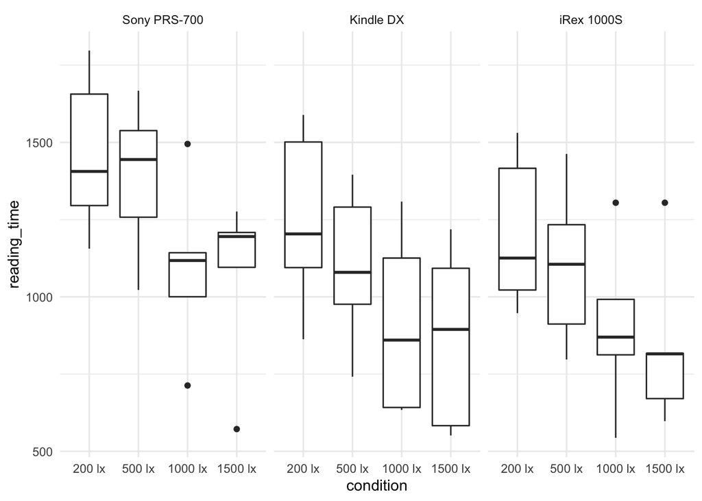

```r
hw2_data %>%
  ggplot(aes(condition, reading_time)) +
  geom_boxplot() +
  facet_wrap(~device) +
  theme_minimal()
```

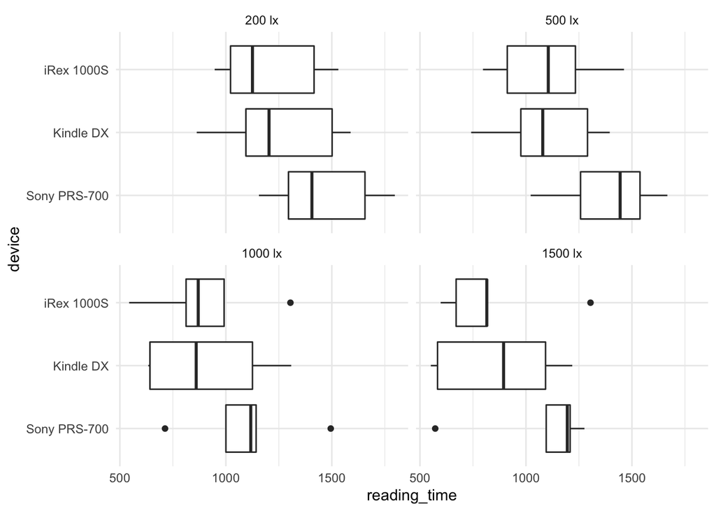

```r
hw2_data %>%
  ggplot(aes(reading_time, device)) +
  geom_boxplot() +
  facet_wrap(~condition) +
  theme_minimal()
```

Reading time by lighting level depended on the device participants used. For iRex 1000S, increasing lighting level seemed to decrease reading time on average. For Kindle DX, increasing lighting level decreased reading time until 1000 lx, with no apparent difference between the 1000 lx and 1500 lx conditions. For Sony PRS-7000, 200 lx and 500 lx had similar reading times, which were higher than those in the 1500 lx group and 1000 lx group, in that order.

Of all devices, Sony PRS-700 had higher reading times on average. iRex 1000S had the lowest reading times for the 100 lx and 1500 lx conditions, but seem about equivalent on average with the Kindle DX for the 500 lx and 1000 lx conditions.

# Question 4.

#### Test the researchers’ first hypothesis, and write a brief interpretation of your results. Remember that we always examine the interaction first, and only examine main effects if it is not significant; we also only examine pairwise comparisons if the associated F statistic is significant. – 60 points

```r
anova_test(hw2_data, formula = reading_time ~ device + condition + device:condition, detailed = TRUE, type = 3, effect.size = "pes")
```

```
## Coefficient covariances computed by hccm()
```

```
## ANOVA Table (type III tests)
##
##             Effect         SSn     SSd DFn DFd       F        p p<.05   pes
## 1      (Intercept) 72557062.35 3650203   1  48 954.122 2.49e-33     * 0.952
## 2           device   706967.92 3650203   2  48   4.648 1.40e-02     * 0.162
## 3        condition  1481063.62 3650203   3  48   6.492 8.91e-04     * 0.289
## 4 device:condition    21543.24 3650203   6  48   0.047 1.00e+00       0.006
```

```r
rstatix::tukey_hsd(hw2_data, reading_time ~ device*condition)
```

```
## # A tibble: 75 × 9
##    term             group1 group2 null.value estimate conf.low conf.high   p.adj
##  * <chr>            <chr>  <chr>       <dbl>    <dbl>    <dbl>     <dbl>   <dbl>
##  1 device           Sony … Kindl…          0   -221.     -432.    -9.72  0.0385
##  2 device           Sony … iRex …          0   -239.     -450.   -27.9   0.0231
##  3 device           Kindl… iRex …          0    -18.2    -229.   193.    0.976
##  4 condition        200 lx 500 lx          0   -112.     -380.   156.    0.684
##  5 condition        200 lx 1000 …          0   -336.     -604.   -68.2   0.00858
##  6 condition        200 lx 1500 …          0   -381.     -649.  -113.    0.00237
##  7 condition        500 lx 1000 …          0   -224.     -492.    43.8   0.131
##  8 condition        500 lx 1500 …          0   -269.     -537.    -0.714 0.0492
##  9 condition        1000 … 1500 …          0    -44.5    -312.   223.    0.971
## 10 device:condition Sony … Kindl…          0   -212.     -811.   387.    0.985
## # … with 65 more rows, and 1 more variable: p.adj.signif <chr>
```

```r
#Condition
condition_means <- hw2_data %>%
 emmeans_test(reading_time ~ condition, p.adjust.method = "holm", detailed = TRUE)

rmarkdown::paged_table(
  get_emmeans(condition_means)
)
```

| condition | emmean | se | df | conf.low | conf.high | method |
| --- | --- | --- | --- | --- | --- | --- |
| 200 lx | 1306.899 | 72.19941 | 56 | 1162.2659 | 1451.531 | Emmeans test |
| 500 lx | 1194.900 | 72.19941 | 56 | 1050.2672 | 1339.533 | Emmeans test |
| 1000 lx | 970.700 | 72.19941 | 56 | 826.0672 | 1115.333 | Emmeans test |
| 1500 lx | 926.200 | 72.19941 | 56 | 781.5672 | 1070.833 | Emmeans test |

```r
#Device
device_means <- hw2_data %>%
 emmeans_test(reading_time ~ device, p.adjust.method = "holm", detailed = TRUE)
rmarkdown::paged_table(
  get_emmeans(device_means)
)
```

| device | emmean | se | df | conf.low | conf.high | method |
| --- | --- | --- | --- | --- | --- | --- |
| Sony PRS-700 | 1252.825 | 67.23101 | 57 | 1118.1977 | 1387.453 | Emmeans test |
| Kindle DX | 1032.199 | 67.23101 | 57 | 897.5717 | 1166.827 | Emmeans test |
| iRex 1000S | 1013.999 | 67.23101 | 57 | 879.3712 | 1148.627 | Emmeans test |

To further investigate the main effects of our model, we ran pairwise comparisons using Tukey’s HSD to correct for family-wise error rate inflation from multiple comparisons. Our pairwise comparisons of showed that reading time on the Sony PRS-700 (M = 1252.83 seconds) was significantly slower than on the Kindle DX, which takes 1032.20 seconds (*p* = .038). reading time on the Sony PRS-700 was also significantly slower by 238.83 seconds,than on the iRex 1000S (M = 1014 seconds) (*p* = .023). There was not a significant difference in reading times between the Kindle DX and iRex 1000S (*p* = .976).

Reading time in the 200 lx low light condition (M = 1306.90 seconds) was significantly slower than the brighter light conditions by 336 seconds than the 970.70 seconds in the 1000 lx condition (*p* = .009) and 380 seconds higher than the 926.200 seconds in the 1500 lx condition (*p* = .002). Additionally, reading time in the 500 lx condition is 1194.90 seconds, which is 269 seconds higher than in the 1500 lx condition (*p* = .049). No other light condition differences are significant.

# Question 5.

#### Test the researchers’ second hypothesis with a hand-coded contrast matrix (including effect sizes). Again, write a brief interpretation of your results. – 40 points

*Researchers’ original hypothesis*: Reading time would be longer on average in the lowest lighting condition(200 lx) than in the brightest condition (1500 lx), but that the effect would be stronger (i.e., bigger difference between the lighting levels) for the device with the smaller display (the Sony) than for the two larger displays combined (Kindle and iRex).

```r
model <- lm(reading_time ~ device + condition + condition:device, hw2_data)

means <- emmeans(model, ~condition*device)
means
```

```
##  condition device       emmean  SE df lower.CL upper.CL
##  200 lx    Sony PRS-700   1462 123 48     1214     1710
##  500 lx    Sony PRS-700   1386 123 48     1138     1634
##  1000 lx   Sony PRS-700   1094 123 48      846     1342
##  1500 lx   Sony PRS-700   1069 123 48      822     1317
##  200 lx    Kindle DX      1250 123 48     1002     1498
##  500 lx    Kindle DX      1097 123 48      849     1345
##  1000 lx   Kindle DX       914 123 48      666     1162
##  1500 lx   Kindle DX       868 123 48      620     1116
##  200 lx    iRex 1000S     1208 123 48      960     1456
##  500 lx    iRex 1000S     1102 123 48      854     1350
##  1000 lx   iRex 1000S      904 123 48      656     1152
##  1500 lx   iRex 1000S      841 123 48      593     1089
##
## Confidence level used: 0.95
```

```r
# pairs(means)

contrasts <- list(
  hyp1 = c(1, 0, 0, -1, -.5, 0, 0, .5, -.5, 0, 0, .5)
)

contrast(means, contrasts)
```

```
##  contrast estimate  SE df t.ratio p.value
##  hyp1           18 214 48   0.084  0.9334
```

```r
#Calculate effect size with Omega
# 1.Convert t-ratio to F-ratio by squaring it: t^2 = F
# (0.084)^2
# Fvalue = 0.007056


# 2. Plug in values accordingly:
omega.F(dfm = 1, # groups compared - 1
        dfe = 48, # take from contrast df
      Fvalue = 0.007056,
      n = 60, # total sample size (from descriptive statistics)
      a = .005) # p-value threshold
```

```
## $omega
## [1] -0.01682755
##
## $omegalow
## [1] 0
##
## $omegahigh
## [1] 0.9999952
##
## $dfm
## [1] 1
##
## $dfe
## [1] 48
##
## $F
## [1] 0.007056
##
## $p
## [1] 0.9334058
##
## $estimate
## [1] "$\\omega^2$ = -0.02, 99.5\\% CI [0.00, 1.00]"
##
## $statistic
## [1] "$F$(1, 48) = 0.01, $p$ = .933"
```